# prosperLoanData

# **Final Plots and Summary**

### Plot One and Two

we have seen Loan Origin amount has siginificant correlation with the borrower rate, i have used employment status also to look deeper into the data and see the patterns, which we have seen for employment status and different loan amount we have differnet borrower rates.

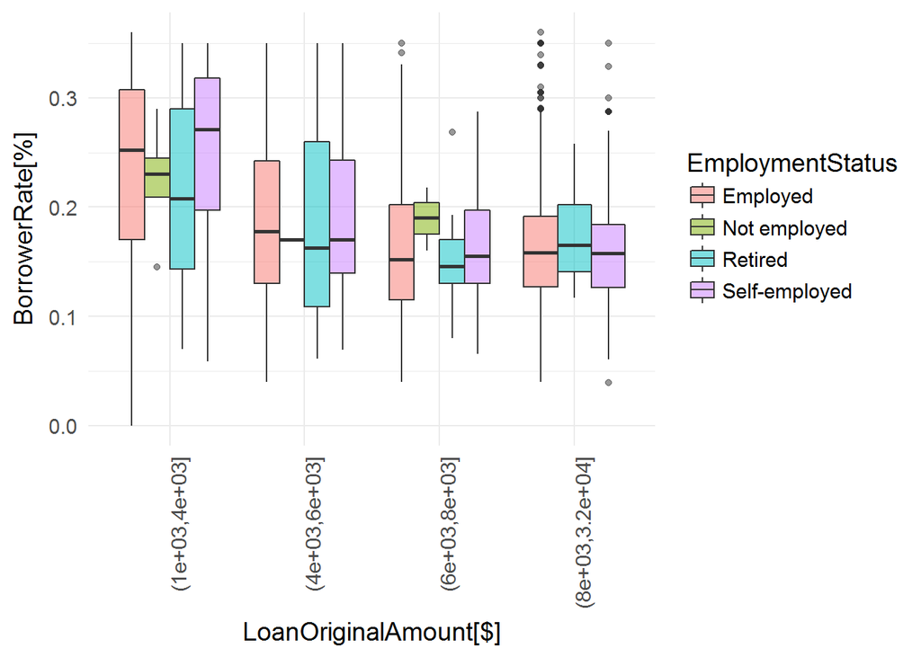

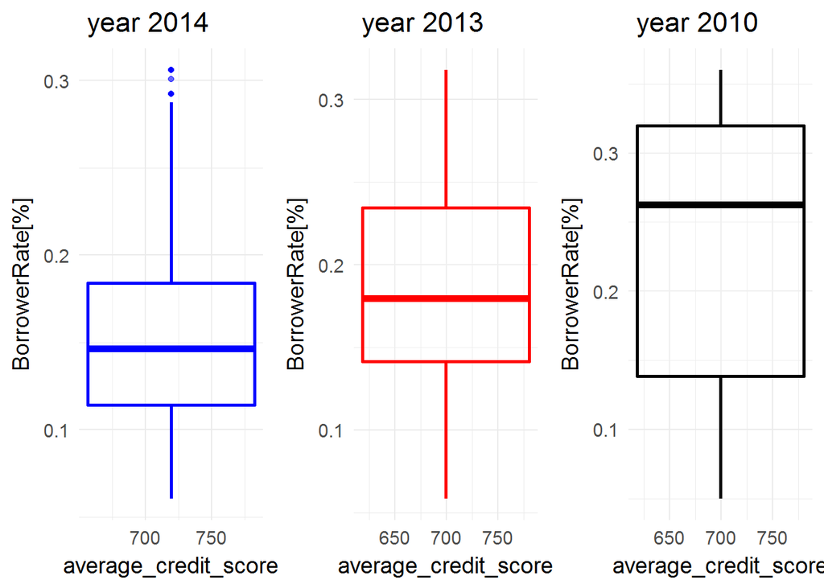

# **Reflections**

## Issues

Are the following conclusions certain? No. There seems we need more data wrangling and cleaning on this data set.Also we need to have more records with usable values. Regarding this project I struggled with finding the relationship between the variables initially. It was hard for me to decide which variables are dependent, which are independent and which I should keep in my analysis.Through exploring, I found a borrower rate as my dependent variable and I designed my project around that.

## Conclusion

My conclusions regarding this project are the following; The likelihood of having low/high Borrow rate depends on variables such as credit score, amount of the loan, customer payment and other variables which model showed us, but I did not consider them in my conclusion.

Intrestingly I found that having higher loan amount seems to decrease the borrow rate, however we need more data to approve this hypothesis.